# Elsevier 2022 SDG mapping

)

OR

(

TITLE-ABS("Tertiary treatment") AND NOT ((TITLE-ABS("rehabilitation") OR TITLE-ABS("spine") OR TITLE-ABS("patients") OR TITLE-ABS("patient") OR TITLE-ABS(" tertiary care")))

)

OR

(

AUTHKEY("Tertiary treatment") AND NOT ((AUTHKEY("rehabilitation") OR AUTHKEY("spine") OR AUTHKEY("patients") OR AUTHKEY("patient") OR AUTHKEY(" tertiary care")))

)

OR TITLE-ABS

(

"Tertiary effluent"

)

OR AUTHKEY

(

"Tertiary effluent"

)

OR

(

TITLE-ABS("water treatment") AND TITLE-ABS("sludge")

)

OR

(

AUTHKEY("water treatment") AND AUTHKEY("sludge")

)

OR TITLE-ABS

(

"water sanitation"

)

OR AUTHKEY

(

"water sanitation"

)

OR TITLE-ABS

(

"domestic effluent"

)

OR AUTHKEY

(

"domestic effluent"

)

OR

(

(TITLE-ABS("water quality") AND (TITLE-ABS("stream") OR TITLE-ABS("streams") OR TITLE-ABS("runoff") OR TITLE-ABS("run-off"))) OR (TITLE-ABS("water quality") AND (TITLE-ABS("stream") OR TITLE-ABS("streams") OR TITLE-ABS("runoff") OR TITLE-ABS("runoff")))

)

OR

(

(AUTHKEY("water quality") AND (AUTHKEY("stream") OR AUTHKEY("streams") OR AUTHKEY("runoff") OR AUTHKEY("run-off"))) OR (AUTHKEY("water quality") AND (AUTHKEY("stream") OR AUTHKEY("streams") OR AUTHKEY("runoff") OR AUTHKEY("runoff")))

)

OR

(

TITLE-ABS("sanitation") AND TITLE-ABS("slums") AND TITLE-ABS("water")

)

OR

(

AUTHKEY("sanitation") AND AUTHKEY("slums") AND AUTHKEY("water")

)

OR

(

TITLE-ABS("treated wastewater") OR TITLE-ABS("treated wastewaters") OR TITLE-ABS("treated waste water") OR TITLE-ABS("treated waste waters")

)

OR

(

AUTHKEY("treated wastewater") OR AUTHKEY("treated wastewaters") OR AUTHKEY("treated waste water") OR AUTHKEY("treated waste waters")

)

OR TITLE-ABS

(

"improve water quality"

)

OR AUTHKEY

(

"improve water quality"

)

OR

(

TITLE-ABS("sanitation technologies") OR TITLE-ABS("sanitation technology")

)

OR

(

AUTHKEY("sanitation technologies") OR AUTHKEY("sanitation technology")

)

OR

(

TITLE-ABS("water treatment") AND (TITLE-ABS("discharge") OR TITLE-ABS("effluent") OR TITLE-ABS("effluents"))

)

OR

(

AUTHKEY("water treatment") AND (AUTHKEY("discharge") OR AUTHKEY("effluent") OR AUTHKEY("effluents"))

)

OR

(

TITLE-ABS("Sequencing batch reactors") OR TITLE-ABS("sequential batch reactors") OR TITLE-ABS("Sequencing batch reactor") OR TITLE-ABS("sequential batch reactor")

)

OR

(

AUTHKEY("Sequencing batch reactors") OR AUTHKEY("sequential batch reactors") OR AUTHKEY("Sequencing batch reactor") OR AUTHKEY("sequential batch reactor")

)

OR

(

((TITLE-ABS("Coagulation") OR TITLE-ABS("flocculation")) AND (TITLE-ABS("water") OR TITLE-ABS("wastewater")) AND TITLE-ABS("treatment")) AND NOT ((TITLE-ABS("tumours") OR TITLE-ABS("tumours") OR TITLE-ABS("therapy") OR TITLE-ABS("ultrasound") OR TITLE-ABS("blood")))

)

OR

(

((AUTHKEY("Coagulation") OR AUTHKEY("flocculation")) AND (AUTHKEY("water") OR AUTHKEY("wastewater")) AND AUTHKEY("treatment")) AND NOT ((AUTHKEY("tumours") OR AUTHKEY("tumours") OR AUTHKEY("therapy") OR AUTHKEY("ultrasound") OR AUTHKEY("blood")))

)

OR

(

TITLE-ABS("water quality") AND (TITLE-ABS("point source") OR TITLE-ABS("nonpoint source"))

)

OR

(

AUTHKEY("water quality") AND (AUTHKEY("point source") OR AUTHKEY("nonpoint source"))

)

OR

(

(TITLE-ABS("wastewater") OR TITLE-ABS("wastewaters") OR TITLE-ABS("waste water") OR TITLE-ABS("waste waters")) AND (TITLE-ABS("water analyses") OR TITLE-ABS("water analysis"))

)

OR

(

(AUTHKEY("wastewater") OR AUTHKEY("wastewaters") OR AUTHKEY("waste water") OR AUTHKEY("waste waters")) AND (AUTHKEY("water analyses") OR AUTHKEY("water analysis"))

)

OR

(

TITLE-ABS("management of wastewater") OR TITLE-ABS("managing wastewater") OR TITLE-ABS("management of wastewaters") OR TITLE-ABS("managing wastewaters")

)

OR

(

AUTHKEY("management of wastewater") OR AUTHKEY("managing wastewater") OR AUTHKEY("management of wastewaters") OR AUTHKEY("managing wastewaters")

)

OR

(

TITLE-ABS("water treatment") AND (TITLE-ABS("ozone") OR TITLE-ABS("ozonation"))

)

OR

(

AUTHKEY("water treatment") AND (AUTHKEY("ozone") OR AUTHKEY("ozonation"))

)

OR

(

TITLE-ABS("latrine") AND (TITLE-ABS("hygiene") OR TITLE-ABS("sanitation") OR TITLE-ABS("toilet") OR TITLE-ABS("flush"))

)

OR

(

AUTHKEY("latrine") AND (AUTHKEY("hygiene") OR AUTHKEY("sanitation") OR AUTHKEY("toilet") OR AUTHKEY("flush"))

)

OR

(

TITLE-ABS("sanitation") AND TITLE-ABS("settlement") AND TITLE-ABS("water")

)

OR

(

AUTHKEY("sanitation") AND AUTHKEY("settlement") AND AUTHKEY("water")

)

OR

(

TITLE-ABS("urban") AND TITLE-ABS("treatment") AND TITLE-ABS("runoff")

)

OR

(

AUTHKEY("urban") AND AUTHKEY("treatment") AND AUTHKEY("runoff")

)

OR TITLE-ABS

(

"ambient water quality"

)

OR AUTHKEY

(

"ambient water quality"

)

OR

(

(TITLE-ABS("water") OR TITLE-ABS("groundwater") OR TITLE-ABS("wastewater") OR TITLE-ABS("greywater")) AND TITLE-ABS("contaminated") AND TITLE-ABS("household")

)

OR

(

(AUTHKEY("water") OR AUTHKEY("groundwater") OR AUTHKEY("wastewater") OR AUTHKEY("greywater")) AND AUTHKEY("contaminated") AND AUTHKEY("household")

)

OR

(

TITLE-ABS("treatement of waste watesr") OR TITLE-ABS("treating waste waters") OR TITLE-ABS("treat waste waters")

)

OR

(

AUTHKEY("treatement of waste watesr") OR AUTHKEY("treating waste waters") OR AUTHKEY("treat waste waters")

)

OR

(

TITLE-ABS("water treatment technology") OR TITLE-ABS("water treatment technologies")

)

OR

(

AUTHKEY("water treatment technology") OR AUTHKEY("water treatment technologies")

)

OR

(

TITLE-ABS("water quality") AND (TITLE-ABS("lagoon") OR TITLE-ABS("lagoons") OR TITLE-ABS("bay"))

)

OR

(

AUTHKEY("water quality") AND (AUTHKEY("lagoon") OR AUTHKEY("lagoons") OR AUTHKEY("bay"))

)

OR

(

(TITLE-ABS("water pre-treatment") AND (TITLE-ABS("ballast") OR TITLE-ABS("ballasts") OR TITLE-ABS("sludge") OR TITLE-ABS("ozone") OR TITLE-ABS("ozonation") OR TITLE-ABS("discharge") OR TITLE-ABS("effluent") OR TITLE-ABS("effluents"))) OR (TITLE-ABS("water pretreatment") AND (TITLE-ABS("ballast") OR TITLE-ABS("ballasts") OR TITLE-ABS("sludge") OR TITLE-ABS("ozone") OR TITLE-ABS("ozonation") OR TITLE-ABS("discharge") OR TITLE-ABS("effluent") OR TITLE-ABS("effluents")))

)

OR

(

(AUTHKEY("water pre-treatment") AND (AUTHKEY("ballast") OR AUTHKEY("ballasts") OR AUTHKEY("sludge") OR AUTHKEY("ozone") OR AUTHKEY("ozonation") OR AUTHKEY("discharge") OR AUTHKEY("effluent") OR AUTHKEY("effluents"))) OR (AUTHKEY("water pretreatment") AND (AUTHKEY("ballast") OR AUTHKEY("ballasts") OR AUTHKEY("sludge") OR AUTHKEY("ozone") OR AUTHKEY("ozonation") OR AUTHKEY("discharge") OR AUTHKEY("effluent") OR AUTHKEY("effluents")))

)

OR

(

(TITLE-ABS("groundwater") OR TITLE-ABS("groundwaters") OR TITLE-ABS("ground water") OR TITLE-ABS("ground waters")) AND (TITLE-ABS("decontaminated") OR TITLE-ABS("decontamination"))

)

OR

(

(AUTHKEY("groundwater") OR AUTHKEY("groundwaters") OR AUTHKEY("ground water") OR AUTHKEY("ground waters")) AND (AUTHKEY("decontaminated") OR AUTHKEY("decontamination"))

)

OR

(

TITLE-ABS("Water quality") AND TITLE-ABS("stormwater")

)

OR

(

AUTHKEY("Water quality") AND AUTHKEY("stormwater")

)

OR

(

TITLE-ABS("sewage water treatment") OR TITLE-ABS("sewage water treatments")

)

OR

(

AUTHKEY("sewage water treatment") OR AUTHKEY("sewage water treatments")

)

OR TITLE-ABS

(

"reducing dumping"

)

OR AUTHKEY

(

"reducing dumping"

)

OR

(

(TITLE-ABS("water") OR TITLE-ABS("groundwater") OR TITLE-ABS("wastewater") OR TITLE-ABS("greywater")) AND TITLE-ABS("contamination") AND TITLE-ABS("household")

)

OR

(

(AUTHKEY("water") OR AUTHKEY("groundwater") OR AUTHKEY("wastewater") OR AUTHKEY("greywater")) AND AUTHKEY("contamination") AND AUTHKEY("household")

)

OR

(

(TITLE-ABS("wastewater") OR TITLE-ABS("wastewaters") OR TITLE-ABS("waste water") OR TITLE-ABS("waste waters")) AND TITLE-ABS("purification")

)

OR

(

(AUTHKEY("wastewater") OR AUTHKEY("wastewaters") OR AUTHKEY("waste water") OR AUTHKEY("waste waters")) AND AUTHKEY("purification")

)

OR TITLE-ABS

(

"rural sanitation"

)

OR AUTHKEY

(

"rural sanitation"

)

OR

(

((TITLE-ABS("Water treatment") OR TITLE-ABS("Water quality")) AND (TITLE-ABS("disinfection by-products") OR TITLE-ABS("disinfection by-product") OR TITLE-ABS("disinfection byproducts") OR TITLE-ABS("disinfection byproduct"))) OR ((TITLE-ABS("Water treatment") OR TITLE-ABS("Water quality")) AND (TITLE-ABS("disinfection byproducts") OR TITLE-ABS("disinfection byproduct") OR TITLE-ABS("disinfection byproducts") OR TITLE-ABS("disinfection byproduct")))

)

OR

(

((AUTHKEY("Water treatment") OR AUTHKEY("Water quality")) AND (AUTHKEY("disinfection by-products") OR AUTHKEY("disinfection by-product") OR AUTHKEY("disinfection byproducts") OR AUTHKEY("disinfection byproduct"))) OR ((AUTHKEY("Water treatment") OR AUTHKEY("Water quality")) AND (AUTHKEY("disinfection byproducts") OR AUTHKEY("disinfection byproduct") OR AUTHKEY("disinfection byproducts") OR AUTHKEY("disinfection byproduct")))

)

OR

(

(TITLE-ABS("greywater") OR TITLE-ABS("greywaters") OR TITLE-ABS("grey water") OR TITLE-ABS("grey waters")) AND (TITLE-ABS("contaminated") OR TITLE-ABS("contamination"))

)

OR

(

(AUTHKEY("greywater") OR AUTHKEY("greywaters") OR AUTHKEY("grey water") OR AUTHKEY("grey waters")) AND (AUTHKEY("contaminated") OR AUTHKEY("contamination"))

)

OR

(

(TITLE-ABS("wastewater") OR TITLE-ABS("wastewaters") OR TITLE-ABS("waste water") OR TITLE-ABS("waste waters")) AND (TITLE-ABS("polluted") OR TITLE-ABS("pollution"))

)

OR

(

(AUTHKEY("wastewater") OR AUTHKEY("wastewaters") OR AUTHKEY("waste water") OR AUTHKEY("waste waters")) AND (AUTHKEY("polluted") OR AUTHKEY("pollution"))

)

OR

(

(TITLE-ABS("wastewater") OR TITLE-ABS("wastewaters") OR TITLE-ABS("waste water") OR TITLE-ABS("waste waters")) AND (TITLE-ABS("mill") OR TITLE-ABS("dye") OR TITLE-ABS("dyeing") OR TITLE-ABS("distillery") OR TITLE-ABS("oily") OR TITLE-ABS("gasification") OR TITLE-ABS("refinery") OR TITLE-ABS("slaughterhouse") OR TITLE-ABS("tannery") OR TITLE-ABS("dairy"))

)

OR

(

(AUTHKEY("wastewater") OR AUTHKEY("wastewaters") OR AUTHKEY("waste water") OR AUTHKEY("waste waters")) AND (AUTHKEY("mill") OR AUTHKEY("dye") OR AUTHKEY("dyeing") OR AUTHKEY("distillery") OR AUTHKEY("oily") OR AUTHKEY("gasification") OR AUTHKEY("refinery") OR AUTHKEY("slaughterhouse") OR AUTHKEY("tannery") OR AUTHKEY("dairy"))

)

OR

(

(TITLE-ABS("industrial effluent") OR TITLE-ABS("industrial effluents")) AND (TITLE-ABS("treatment") OR TITLE-ABS("decontamination"))

)

OR

(

(AUTHKEY("industrial effluent") OR AUTHKEY("industrial effluents")) AND (AUTHKEY("treatment") OR AUTHKEY("decontamination"))

)

OR

(

(TITLE-ABS("groundwater") OR TITLE-ABS("groundwaters") OR TITLE-ABS("ground water") OR TITLE-ABS("ground waters")) AND (TITLE-ABS("contaminants") OR TITLE-ABS("contaminant"))

)

OR

(

(AUTHKEY("groundwater") OR AUTHKEY("groundwaters") OR AUTHKEY("ground water") OR AUTHKEY("ground waters")) AND (AUTHKEY("contaminants") OR AUTHKEY("contaminant"))

)

OR

(

TITLE-ABS("groundwater cleanup") OR TITLE-ABS("groundwaters cleanup") OR TITLE-ABS("ground water cleanup") OR TITLE-ABS("ground waters cleanup")

)

OR

(

AUTHKEY("groundwater cleanup") OR AUTHKEY("groundwaters cleanup") OR AUTHKEY("ground water cleanup") OR AUTHKEY("ground waters cleanup")

)

OR

(

TITLE-ABS("sanitation infrastructures") OR TITLE-ABS("sanitation infrastructure")

)

OR

(

AUTHKEY("sanitation infrastructures") OR AUTHKEY("sanitation infrastructure")

)

OR

(

(TITLE-ABS("pre-treatment") AND TITLE-ABS("waste-water") AND TITLE-ABS("membrane*")) OR (TITLE-ABS("pretreatment") AND TITLE-ABS("wastewater") AND TITLE-ABS("membrane*"))

)

OR

(

(AUTHKEY("pre-treatment") AND AUTHKEY("waste-water") AND AUTHKEY("membrane*")) OR (AUTHKEY("pretreatment") AND AUTHKEY("wastewater") AND AUTHKEY("membrane*"))

)

OR

(

TITLE-ABS("water quality") AND (TITLE-ABS("contaminant") OR TITLE-ABS("contaminants"))

)

OR

(

AUTHKEY("water quality") AND (AUTHKEY("contaminant") OR AUTHKEY("contaminants"))

)

OR

(

TITLE-ABS("water treatment") AND (TITLE-ABS("filter") OR TITLE-ABS("filters") OR TITLE-ABS("filtration"))

)

OR

(

AUTHKEY("water treatment") AND (AUTHKEY("filter") OR AUTHKEY("filters") OR AUTHKEY("filtration"))

)

OR

(

(TITLE-ABS("waste water") OR TITLE-ABS("wastewater") OR TITLE-ABS("waste waters") OR TITLE-ABS("wastewaters")) AND (TITLE-ABS("urban") OR TITLE-ABS("city") OR TITLE-ABS("cities"))

)

OR

(

(AUTHKEY("waste water") OR AUTHKEY("wastewater") OR AUTHKEY("waste waters") OR AUTHKEY("wastewaters")) AND (AUTHKEY("urban") OR AUTHKEY("city") OR AUTHKEY("cities"))

)

OR

(

(TITLE-ABS("water") OR TITLE-ABS("groundwater") OR TITLE-ABS("wastewater") OR TITLE-ABS("greywater") OR TITLE-ABS("waters") OR TITLE-ABS("groundwaters") OR TITLE-ABS("wastewaters") OR TITLE-ABS("greywaters")) AND (TITLE-ABS("contaminated") OR TITLE-ABS("contamination")) AND TITLE-ABS("municipal")

)

OR

(

(AUTHKEY("water") OR AUTHKEY("groundwater") OR AUTHKEY("wastewater") OR AUTHKEY("greywater") OR AUTHKEY("waters") OR AUTHKEY("groundwaters") OR AUTHKEY("wastewaters") OR AUTHKEY("greywaters")) AND (AUTHKEY("contaminated") OR AUTHKEY("contamination")) AND AUTHKEY("municipal")

)

OR

(

(TITLE-ABS("groundwater") OR TITLE-ABS("groundwaters") OR TITLE-ABS("ground water") OR TITLE-ABS("ground waters")) AND (TITLE-ABS("polluted") OR TITLE-ABS("pollution"))

)

OR

(

(AUTHKEY("groundwater") OR AUTHKEY("groundwaters") OR AUTHKEY("ground water") OR AUTHKEY("ground waters")) AND (AUTHKEY("polluted") OR AUTHKEY("pollution"))

)

OR

(

TITLE-ABS("fit-for-purpose treatment") OR TITLE-ABS("fitforpurpose treatment")

)

OR

(

AUTHKEY("fit-for-purpose treatment") OR AUTHKEY("fitforpurpose treatment")

)

OR

(

TITLE-ABS("contamination") AND TITLE-ABS("water bodies")

)

OR

(

AUTHKEY("contamination") AND AUTHKEY("water bodies")

)

OR

(

(TITLE-ABS("greywater") OR TITLE-ABS("greywaters") OR TITLE-ABS("grey water") OR TITLE-ABS("grey waters")) AND (TITLE-ABS("decontaminated") OR TITLE-ABS("decontamination"))

)

OR

(

(AUTHKEY("greywater") OR AUTHKEY("greywaters") OR AUTHKEY("grey water") OR AUTHKEY("grey waters")) AND (AUTHKEY("decontaminated") OR AUTHKEY("decontamination"))

)

OR

(

TITLE-ABS("treat wastewater") OR TITLE-ABS("treat wastewaters") OR TITLE-ABS("treats wastewater") OR TITLE-ABS("treats wastewaters")

)

OR

(

AUTHKEY("treat wastewater") OR AUTHKEY("treat wastewaters") OR AUTHKEY("treats wastewater") OR AUTHKEY("treats wastewaters")

)

OR

(

TITLE-ABS("water treatment") AND TITLE-ABS("sanitation")

)

OR

(

AUTHKEY("water treatment") AND AUTHKEY("sanitation")

)

OR

(

((TITLE-ABS("wastewater") OR TITLE-ABS("wastewaters") OR TITLE-ABS("waste water") OR TITLE-ABS("waste waters")) AND (TITLE-ABS("removal") OR TITLE-ABS("reduction"))) AND NOT (((TITLE-ABS("energy recovery") OR TITLE-ABS("heat recovery") OR TITLE-ABS("heat energy")) AND (TITLE-ABS("Renewable Energy") OR TITLE-ABS("heat pump"))))

)

OR

(

((AUTHKEY("wastewater") OR AUTHKEY("wastewaters") OR AUTHKEY("waste water") OR AUTHKEY("waste waters")) AND (AUTHKEY("removal") OR AUTHKEY("reduction"))) AND NOT (((AUTHKEY("energy recovery") OR AUTHKEY("heat recovery") OR AUTHKEY("heat energy")) AND (AUTHKEY("Renewable Energy") OR AUTHKEY("heat pump"))))

)

OR

(

TITLE-ABS("polluted water") OR TITLE-ABS("polluted groundwater") OR TITLE-ABS("polluted ground water")

)

OR

(

AUTHKEY("polluted water") OR AUTHKEY("polluted groundwater") OR AUTHKEY("polluted ground water")

)

OR

(

(TITLE-ABS("Water treatment") AND (TITLE-ABS("stormwater") OR TITLE-ABS("storm-water"))) OR (TITLE-ABS("Water treatment") AND (TITLE-ABS("stormwater") OR TITLE-ABS("stormwater")))

)

OR

(

(AUTHKEY("Water treatment") AND (AUTHKEY("stormwater") OR AUTHKEY("storm-water"))) OR (AUTHKEY("Water treatment") AND (AUTHKEY("stormwater") OR AUTHKEY("stormwater")))

)

OR

(

TITLE-ABS("water treatment") AND (TITLE-ABS("contaminants") OR TITLE-ABS("contamination") OR TITLE-ABS("contaminated"))

)

OR

(

AUTHKEY("water treatment") AND (AUTHKEY("contaminants") OR AUTHKEY("contamination") OR AUTHKEY("contaminated"))

)

OR

(

TITLE-ABS("dyeing wastewater") OR TITLE-ABS("dyeing waste water") OR TITLE-ABS("dyeing wastewaters") OR TITLE-ABS("dyeing waste waters")

)

OR

(

AUTHKEY("dyeing wastewater") OR AUTHKEY("dyeing waste water") OR AUTHKEY("dyeing wastewaters") OR AUTHKEY("dyeing waste waters")

)

OR

(

TITLE-ABS("water quality") AND (TITLE-ABS("water bodies") OR TITLE-ABS("waterbodies") OR TITLE-ABS("bodies of water") OR TITLE-ABS("water body") OR TITLE-ABS("waterbody") OR TITLE-ABS("body of water"))

)

OR

(

AUTHKEY("water quality") AND (AUTHKEY("water bodies") OR AUTHKEY("waterbodies") OR AUTHKEY("bodies of water") OR AUTHKEY("water body") OR AUTHKEY("waterbody") OR AUTHKEY("body of water"))

)

OR

(

TITLE-ABS("reduction in wastewater") OR TITLE-ABS("reduction in waste water")

)

OR

(

AUTHKEY("reduction in wastewater") OR AUTHKEY("reduction in waste water")

)

OR

(

((TITLE-ABS("waste water") OR TITLE-ABS("wastewaters") OR TITLE-ABS("waste water") OR TITLE-ABS("waste waters")) AND TITLE-ABS("reduction")) AND NOT (((TITLE-ABS("energy recovery") OR TITLE-ABS("heat recovery") OR TITLE-ABS("heat energy")) AND (TITLE-ABS("Renewable Energy") OR TITLE-ABS("heat pump"))))

)

OR

(

((AUTHKEY("waste water") OR AUTHKEY("wastewaters") OR AUTHKEY("waste water") OR AUTHKEY("waste waters")) AND AUTHKEY("reduction")) AND NOT (((AUTHKEY("energy recovery") OR AUTHKEY("heat recovery") OR AUTHKEY("heat energy")) AND (AUTHKEY("Renewable Energy") OR AUTHKEY("heat pump"))))

)

OR

(

TITLE-ABS("water quality") AND (TITLE-ABS("sewer") OR TITLE-ABS("sewage"))

)

OR

(

AUTHKEY("water quality") AND (AUTHKEY("sewer") OR AUTHKEY("sewage"))

)

OR

(

TITLE-ABS("dye wastewater") OR TITLE-ABS("dye waste water") OR TITLE-ABS("dye wastewaters") OR TITLE-ABS("dye waste waters")

)

OR

(

AUTHKEY("dye wastewater") OR AUTHKEY("dye waste water") OR AUTHKEY("dye wastewaters") OR AUTHKEY("dye waste waters")

)

OR

(

TITLE-ABS("tmdl") AND NOT ((TITLE-ABS("rat") OR TITLE-ABS("rats") OR TITLE-ABS("bone") OR TITLE-ABS("bones")))

)

OR

(

AUTHKEY("tmdl") AND NOT ((AUTHKEY("rat") OR AUTHKEY("rats") OR AUTHKEY("bone") OR AUTHKEY("bones")))

)

OR

(

TITLE-ABS("water treatment") AND (TITLE-ABS("microfiltration") OR TITLE-ABS("ultrafiltration") OR TITLE-ABS("nanofiltration"))

)

OR

(

AUTHKEY("water treatment") AND (AUTHKEY("microfiltration") OR AUTHKEY("ultrafiltration") OR AUTHKEY("nanofiltration"))

)

OR TITLE-ABS

(

"total maximum daily loading"

)

OR AUTHKEY

(

"total maximum daily loading"

)

OR

(

TITLE-ABS("water quality") AND (TITLE-ABS("pollution") OR TITLE-ABS("polluted"))

)

OR

(

AUTHKEY("water quality") AND (AUTHKEY("pollution") OR AUTHKEY("polluted"))

)

OR

(

TITLE-ABS("Persistent, Bioaccumulative, and Toxic") AND TITLE-ABS("water")

)

OR

(

AUTHKEY("Persistent, Bioaccumulative, and Toxic") AND AUTHKEY("water")

)

OR

(

TITLE-ABS("coking wastewater") OR TITLE-ABS("coking waste water") OR TITLE-ABS("coking wastewaters") OR TITLE-ABS("coking waste waters")

)

OR

(

AUTHKEY("coking wastewater") OR AUTHKEY("coking waste water") OR AUTHKEY("coking wastewaters") OR AUTHKEY("coking waste waters")

)

OR TITLE-ABS

(

"water disinfection"

)

OR AUTHKEY

(

"water disinfection"

)

OR

(

TITLE-ABS("PBT") AND (TITLE-ABS("river") OR TITLE-ABS("lake") OR TITLE-ABS("rivers") OR TITLE-ABS("lakes") OR TITLE-ABS("water quality") OR TITLE-ABS("water contamination") OR TITLE-ABS("water pollution") OR TITLE-ABS("estuary") OR TITLE-ABS("estuaries"))

)

OR

(

AUTHKEY("PBT") AND (AUTHKEY("river") OR AUTHKEY("lake") OR AUTHKEY("rivers") OR AUTHKEY("lakes") OR AUTHKEY("water quality") OR AUTHKEY("water contamination") OR AUTHKEY("water pollution") OR AUTHKEY("estuary") OR AUTHKEY("estuaries"))

)

OR

(

(TITLE-ABS("Water treatment") OR TITLE-ABS("Water quality")) AND TITLE-ABS("THMs")

)

OR

(

(AUTHKEY("Water treatment") OR AUTHKEY("Water quality")) AND AUTHKEY("THMs")

)

OR

(

(TITLE-ABS("trihalomethanes") OR TITLE-ABS("trihalomethane")) AND (TITLE-ABS("groundwater") OR TITLE-ABS("groundwaters") OR TITLE-ABS("ground water") OR TITLE-ABS("ground waters"))

)

OR

(

(AUTHKEY("trihalomethanes") OR AUTHKEY("trihalomethane")) AND (AUTHKEY("groundwater") OR AUTHKEY("groundwaters") OR AUTHKEY("ground water") OR AUTHKEY("ground waters"))

)

OR

(

(TITLE-ABS("treatment") AND (TITLE-ABS("urban runoff") OR TITLE-ABS("urban run-off"))) OR (TITLE-ABS("treatment") AND (TITLE-ABS("urban runoff") OR TITLE-ABS("urban runoff")))

)

OR

(

(AUTHKEY("treatment") AND (AUTHKEY("urban runoff") OR AUTHKEY("urban run-off"))) OR (AUTHKEY("treatment") AND (AUTHKEY("urban runoff") OR AUTHKEY("urban runoff")))

)

OR

(

(TITLE-ABS("separation toilet") OR TITLE-ABS("separation toilets") OR TITLE-ABS("vacuum toilet") OR TITLE-ABS("vacuum toilets") OR TITLE-ABS("bio-toilet") OR TITLE-ABS("bio-toilets")) OR (TITLE-ABS("separation toilet") OR TITLE-ABS("separation toilets") OR TITLE-ABS("vacuum toilet") OR TITLE-ABS("vacuum toilets") OR TITLE-ABS("biotoilet") OR TITLE-ABS("biotoilets"))

)

OR

(

(AUTHKEY("separation toilet") OR AUTHKEY("separation toilets") OR AUTHKEY("vacuum toilet") OR AUTHKEY("vacuum toilets") OR AUTHKEY("bio-toilet") OR AUTHKEY("bio-toilets")) OR (AUTHKEY("separation toilet") OR AUTHKEY("separation toilets") OR AUTHKEY("vacuum toilet") OR AUTHKEY("vacuum toilets") OR AUTHKEY("biotoilet") OR AUTHKEY("biotoilets"))

)

OR

(

TITLE-ABS("Composting toilet") OR TITLE-ABS("Composting toilets")

)

OR

(

AUTHKEY("Composting toilet") OR AUTHKEY("Composting toilets")

)

OR

(

TITLE-ABS("asbr") AND (TITLE-ABS("sludge") OR TITLE-ABS("water") OR TITLE-ABS("wastewater"))

)

OR

(

AUTHKEY("asbr") AND (AUTHKEY("sludge") OR AUTHKEY("water") OR AUTHKEY("wastewater"))

)

OR

(

(TITLE-ABS("Water quality") AND TITLE-ABS("storm-water")) OR (TITLE-ABS("Water quality") AND TITLE-ABS("stormwater"))

)

OR

(

(AUTHKEY("Water quality") AND AUTHKEY("storm-water")) OR (AUTHKEY("Water quality") AND AUTHKEY("stormwater"))

)

OR

(

TITLE-ABS("groundwater clean up") OR TITLE-ABS("groundwaters clean up") OR TITLE-ABS("ground water clean up") OR TITLE-ABS("ground waters clean up")

)

OR

(

AUTHKEY("groundwater clean up") OR AUTHKEY("groundwaters clean up") OR AUTHKEY("ground water clean up") OR AUTHKEY("ground waters clean up")

)

OR

(

TITLE-ABS("waste water from industrial ") OR TITLE-ABS("waste waters from industrial")

)

OR

(

AUTHKEY("waste water from industrial ") OR AUTHKEY("waste waters from industrial")

)

OR

(

(TITLE-ABS("wastewater ") OR TITLE-ABS("wastewaters") OR TITLE-ABS("waste water") OR TITLE-ABS("waste waters")) AND TITLE-ABS("pollutants")

)

OR

(

(AUTHKEY("wastewater ") OR AUTHKEY("wastewaters") OR AUTHKEY("waste water") OR AUTHKEY("waste waters")) AND AUTHKEY("pollutants")

)

OR

(

(TITLE-ABS("waste water") OR TITLE-ABS("wastewaters") OR TITLE-ABS("waste water") OR TITLE-ABS("waste waters")) AND TITLE-ABS("water analyses")

)

OR

(

(AUTHKEY("waste water") OR AUTHKEY("wastewaters") OR AUTHKEY("waste water") OR AUTHKEY("waste waters")) AND AUTHKEY("water analyses")

)

OR

(

TITLE-ABS("Water treatment") AND TITLE-ABS("watershed")

)

OR

(

AUTHKEY("Water treatment") AND AUTHKEY("watershed")

)

OR

(

(TITLE-ABS("groundwater") OR TITLE-ABS("groundwaters") OR TITLE-ABS("ground water") OR TITLE-ABS("ground waters")) AND (TITLE-ABS("remediation") OR TITLE-ABS("remediations"))

)

OR

(

(AUTHKEY("groundwater") OR AUTHKEY("groundwaters") OR AUTHKEY("ground water") OR AUTHKEY("ground waters")) AND (AUTHKEY("remediation") OR AUTHKEY("remediations"))

)

OR

(

(TITLE-ABS("nitrate") OR TITLE-ABS("nitrates")) AND (TITLE-ABS("ground water") OR TITLE-ABS("ground waters") OR TITLE-ABS("groundwater") OR TITLE-ABS("groundwaters"))

)

OR

(

(AUTHKEY("nitrate") OR AUTHKEY("nitrates")) AND (AUTHKEY("ground water") OR AUTHKEY("ground waters") OR AUTHKEY("groundwater") OR AUTHKEY("groundwaters"))

)

OR

(

TITLE-ABS("water treatment facility") OR TITLE-ABS("water treatment facilities")

)

OR

(

AUTHKEY("water treatment facility") OR AUTHKEY("water treatment facilities")

)

OR

(

(TITLE-ABS("trihalomethanes") OR TITLE-ABS("trihalomethane")) AND (TITLE-ABS("wastewater") OR TITLE-ABS("wastewaters") OR TITLE-ABS("waste water") OR TITLE-ABS("waste waters"))

)

OR

(

(AUTHKEY("trihalomethanes") OR AUTHKEY("trihalomethane")) AND (AUTHKEY("wastewater") OR AUTHKEY("wastewaters") OR AUTHKEY("waste water") OR AUTHKEY("waste waters"))

)

OR

(

(TITLE-ABS("water treatment") AND (TITLE-ABS("membranes") OR TITLE-ABS("membrane"))) AND NOT (TITLE-ABS("hot water"))

)

OR

(

(AUTHKEY("water treatment") AND (AUTHKEY("membranes") OR AUTHKEY("membrane"))) AND NOT (AUTHKEY("hot water"))

)

OR

(

((TITLE-ABS("effluent") OR TITLE-ABS("effluents")) AND (TITLE-ABS("treatment") OR TITLE-ABS("decontamination"))) AND NOT ((TITLE-ABS("patient") OR TITLE-ABS("patients") OR TITLE-ABS("chemotherapy") OR TITLE-ABS("heart") OR TITLE-ABS("hearts")))

)

OR

(

((AUTHKEY("effluent") OR AUTHKEY("effluents")) AND (AUTHKEY("treatment") OR AUTHKEY("decontamination"))) AND NOT ((AUTHKEY("patient") OR AUTHKEY("patients") OR AUTHKEY("chemotherapy") OR AUTHKEY("heart") OR AUTHKEY("hearts")))

)

OR

(

TITLE-ABS("wastewater cleanup") OR TITLE-ABS("wastewaters cleanup") OR TITLE-ABS("waste water cleanup") OR TITLE-ABS("waste waters cleanup")

)

OR

(

AUTHKEY("wastewater cleanup") OR AUTHKEY("wastewaters cleanup") OR AUTHKEY("waste water cleanup") OR AUTHKEY("waste waters cleanup")

)

OR TITLE-ABS

(

"menstrual waste"

)

OR AUTHKEY

(

"menstrual waste"

)

OR

(

TITLE-ABS("sanitary effluent") OR TITLE-ABS("sanitary effluents")

)

OR

(

AUTHKEY("sanitary effluent") OR AUTHKEY("sanitary effluents")

)

OR TITLE-ABS

(

"water supply and sanitation"

)

OR AUTHKEY

(

"water supply and sanitation"

)

OR

(

(TITLE-ABS("THMs") OR TITLE-ABS("THM")) AND (TITLE-ABS("wastewater") OR TITLE-ABS("wastewaters") OR TITLE-ABS("waste water") OR TITLE-ABS("waste waters"))

)

OR

(

(AUTHKEY("THMs") OR AUTHKEY("THM")) AND (AUTHKEY("wastewater") OR AUTHKEY("wastewaters") OR AUTHKEY("waste water") OR AUTHKEY("waste waters"))

)

OR

(

TITLE-ABS("wastewater clean up") OR TITLE-ABS("wastewater clean up") OR TITLE-ABS("waste water clean up") OR TITLE-ABS("waste waters clean up")

)

OR

(

AUTHKEY("wastewater clean up") OR AUTHKEY("wastewater clean up") OR AUTHKEY("waste water clean up") OR AUTHKEY("waste waters clean up")

)

OR

(

TITLE-ABS("water treatment") AND (TITLE-ABS("ballast") OR TITLE-ABS("ballasts"))

)

OR

(

AUTHKEY("water treatment") AND (AUTHKEY("ballast") OR AUTHKEY("ballasts"))

)

OR TITLE-ABS

(

"improve the quality of water"

)

OR AUTHKEY

(

"improve the quality of water"

)

OR

(

(TITLE-ABS("urban") AND TITLE-ABS("treatment") AND TITLE-ABS("run-off")) OR (TITLE-ABS("urban") AND TITLE-ABS("treatment") AND TITLE-ABS("runoff"))

)

OR

(

(AUTHKEY("urban") AND AUTHKEY("treatment") AND AUTHKEY("run-off")) OR (AUTHKEY("urban") AND AUTHKEY("treatment") AND AUTHKEY("runoff"))

)

OR

(

TITLE-ABS("water") AND (TITLE-ABS("pollution") OR TITLE-ABS("polluted") OR TITLE-ABS("contamination") OR TITLE-ABS("contaminated") OR TITLE-ABS("discharge")) AND (TITLE-ABS("point source") OR TITLE-ABS("nonpoint source"))

)

OR

(

AUTHKEY("water") AND (AUTHKEY("pollution") OR AUTHKEY("polluted") OR AUTHKEY("contamination") OR AUTHKEY("contaminated") OR AUTHKEY("discharge")) AND (AUTHKEY("point source") OR AUTHKEY("nonpoint source"))

)

OR TITLE-ABS

(

"untreated wastewater"

)

OR AUTHKEY

(

"untreated wastewater"

)

OR TITLE-ABS

(

"open defecation"

)

OR AUTHKEY

(

"open defecation"

)

OR

(

TITLE-ABS("wastewater infrastructure") OR TITLE-ABS("wastewater infrastructures") OR TITLE-ABS("waste water infrastructure") OR TITLE-ABS("waste water infrastructures")

)

OR

(

AUTHKEY("wastewater infrastructure") OR AUTHKEY("wastewater infrastructures") OR AUTHKEY("waste water infrastructure") OR AUTHKEY("waste water infrastructures")

)

OR

(

TITLE-ABS("water quality") AND TITLE-ABS("sanitation")

)

OR

(

AUTHKEY("water quality") AND AUTHKEY("sanitation")

)

OR

(

TITLE-ABS("aerobic") AND (TITLE-ABS("wastewater") OR TITLE-ABS("wastewaters") OR TITLE-ABS("waste water") OR TITLE-ABS("waste waters"))

)

OR

(

AUTHKEY("aerobic") AND (AUTHKEY("wastewater") OR AUTHKEY("wastewaters") OR AUTHKEY("waste water") OR AUTHKEY("waste waters"))

)

OR

(

TITLE-ABS("recycled polluted water") OR TITLE-ABS("recycled sewage water") OR TITLE-ABS("recycled contaminated water") OR TITLE-ABS("recycled wastewater") OR TITLE-ABS("recycled waste water") OR TITLE-ABS("recycled greywater") OR TITLE-ABS("recycled grey water") OR TITLE-ABS("recycled polluted waters") OR TITLE-ABS("recycled sewage waters") OR TITLE-ABS("recycled contaminated waters") OR TITLE-ABS("recycled wastewaters") OR TITLE-ABS("recycled waste waters") OR TITLE-ABS("recycled greywaters") OR TITLE-ABS("recycled grey waters")

)

OR

(

AUTHKEY("recycled polluted water") OR AUTHKEY("recycled sewage water") OR AUTHKEY("recycled contaminated water") OR AUTHKEY("recycled wastewater") OR AUTHKEY("recycled waste water") OR AUTHKEY("recycled greywater") OR AUTHKEY("recycled grey water") OR AUTHKEY("recycled polluted waters") OR AUTHKEY("recycled sewage waters") OR AUTHKEY("recycled contaminated waters") OR AUTHKEY("recycled wastewaters") OR AUTHKEY("recycled waste waters") OR AUTHKEY("recycled greywaters") OR AUTHKEY("recycled grey waters")

)

OR

(

TITLE-ABS("mercury contamination") AND (TITLE-ABS("water") OR TITLE-ABS("groundwater"))

)

OR

(

AUTHKEY("mercury contamination") AND (AUTHKEY("water") OR AUTHKEY("groundwater"))

)

OR TITLE-ABS

(

"total maximum daily load"

)

OR AUTHKEY

(

"total maximum daily load"

)

OR

(

TITLE-ABS("pollution of water") OR TITLE-ABS("pollution of groundwater") OR TITLE-ABS("pollution of ground water")

)

OR

(

AUTHKEY("pollution of water") OR AUTHKEY("pollution of groundwater") OR AUTHKEY("pollution of ground water")

)

OR

(

(TITLE-ABS("Pit latrine") OR TITLE-ABS("VIP toilets") OR TITLE-ABS("pour-flush") OR TITLE-ABS("Pit latrines") OR TITLE-ABS("VIP toilet")) OR (TITLE-ABS("Pit latrine") OR TITLE-ABS("VIP toilets") OR TITLE-ABS("pourflush") OR TITLE-ABS("Pit latrines") OR TITLE-ABS("VIP toilet"))

)

OR

(

(AUTHKEY("Pit latrine") OR AUTHKEY("VIP toilets") OR AUTHKEY("pour-flush") OR AUTHKEY("Pit latrines") OR AUTHKEY("VIP toilet")) OR (AUTHKEY("Pit latrine") OR AUTHKEY("VIP toilets") OR AUTHKEY("pourflush") OR AUTHKEY("Pit latrines") OR AUTHKEY("VIP toilet"))

)

OR TITLE-ABS

(

"total maximum daily loads"

)

OR AUTHKEY

(

"total maximum daily loads"

)

OR

(

(TITLE-ABS("wastewater") OR TITLE-ABS("wastewaters") OR TITLE-ABS("waste water") OR TITLE-ABS("waste waters")) AND (TITLE-ABS("decontaminated") OR TITLE-ABS("decontamination"))

)

OR

(

(AUTHKEY("wastewater") OR AUTHKEY("wastewaters") OR AUTHKEY("waste water") OR AUTHKEY("waste waters")) AND (AUTHKEY("decontaminated") OR AUTHKEY("decontamination"))

)

OR

(

TITLE-ABS("water quality") AND TITLE-ABS("contamination")

)

OR

(

AUTHKEY("water quality") AND AUTHKEY("contamination")

)

OR

(

(TITLE-ABS("waste water") OR TITLE-ABS("wastewaters") OR TITLE-ABS("waste water") OR TITLE-ABS("waste waters")) AND (TITLE-ABS("mill") OR TITLE-ABS("dye") OR TITLE-ABS("dyeing") OR TITLE-ABS("distillery") OR TITLE-ABS("oily") OR TITLE-ABS("gasification") OR TITLE-ABS("refinery") OR TITLE-ABS("slaughterhouse") OR TITLE-ABS("tannery") OR TITLE-ABS("dairy"))

)

OR

(

(AUTHKEY("waste water") OR AUTHKEY("wastewaters") OR AUTHKEY("waste water") OR AUTHKEY("waste waters")) AND (AUTHKEY("mill") OR AUTHKEY("dye") OR AUTHKEY("dyeing") OR AUTHKEY("distillery") OR AUTHKEY("oily") OR AUTHKEY("gasification") OR AUTHKEY("refinery") OR AUTHKEY("slaughterhouse") OR AUTHKEY("tannery") OR AUTHKEY("dairy"))

)

OR

(

TITLE-ABS("arsenic") AND TITLE-ABS("water") AND (TITLE-ABS("treatment") OR TITLE-ABS("removal") OR TITLE-ABS("contamination") OR TITLE-ABS("contaminated") OR TITLE-ABS("contaminants"))

)

OR

(

AUTHKEY("arsenic") AND AUTHKEY("water") AND (AUTHKEY("treatment") OR AUTHKEY("removal") OR AUTHKEY("contamination") OR AUTHKEY("contaminated") OR AUTHKEY("contaminants"))

)

OR TITLE-ABS

(

"total maximum daily loadings"

)

OR AUTHKEY

(

"total maximum daily loadings"

)

OR

(

TITLE-ABS("water quality") AND (TITLE-ABS("agriculture") OR TITLE-ABS("agricultural"))

)

OR

(

AUTHKEY("water quality") AND (AUTHKEY("agriculture") OR AUTHKEY("agricultural"))

)

OR

(

(TITLE-ABS("pre-treatment") AND TITLE-ABS("sewage* water*")) OR (TITLE-ABS("pretreatment") AND TITLE-ABS("sewage* water*"))

)

OR

(

(AUTHKEY("pre-treatment") AND AUTHKEY("sewage* water*")) OR (AUTHKEY("pretreatment") AND AUTHKEY("sewage* water*"))

)

OR

(

TITLE-ABS("Water quality") AND (TITLE-ABS("trihalomethane") OR TITLE-ABS("trihalomethanes"))

)

OR

(

AUTHKEY("Water quality") AND (AUTHKEY("trihalomethane") OR AUTHKEY("trihalomethanes"))

)

OR

(

TITLE-ABS("textile") AND (TITLE-ABS("water") OR TITLE-ABS("wastewater")) AND (TITLE-ABS("reuse") OR TITLE-ABS("effluents") OR TITLE-ABS("effluent"))

)

OR

(

AUTHKEY("textile") AND (AUTHKEY("water") OR AUTHKEY("wastewater")) AND (AUTHKEY("reuse") OR AUTHKEY("effluents") OR AUTHKEY("effluent"))

)

OR

(

TITLE-ABS("gasification wastewater") OR TITLE-ABS("gasification waste water") OR TITLE-ABS("gasification wastewaters") OR TITLE-ABS("gasification waste waters")

)

OR

(

AUTHKEY("gasification wastewater") OR AUTHKEY("gasification waste water") OR AUTHKEY("gasification wastewaters") OR AUTHKEY("gasification waste waters")

)

OR

(

TITLE-ABS("Water treatment") AND (TITLE-ABS("trihalomethane") OR TITLE-ABS("trihalomethanes"))

)

OR

(

AUTHKEY("Water treatment") AND (AUTHKEY("trihalomethane") OR AUTHKEY("trihalomethanes"))

)

OR

(

TITLE-ABS("tannery wastewater") OR TITLE-ABS("tannery waste water") OR TITLE-ABS("tannery wastewaters") OR TITLE-ABS("tannery waste waters")

)

OR

(

AUTHKEY("tannery wastewater") OR AUTHKEY("tannery waste water") OR AUTHKEY("tannery wastewaters") OR AUTHKEY("tannery waste waters")

)

OR

(

((TITLE-ABS("nonpoint source") OR TITLE-ABS("non-point source")) AND TITLE-ABS("watershed")) OR ((TITLE-ABS("nonpoint source") OR TITLE-ABS("nonpoint source")) AND TITLE-ABS("watershed"))

)

OR

(

((AUTHKEY("nonpoint source") OR AUTHKEY("non-point source")) AND AUTHKEY("watershed")) OR ((AUTHKEY("nonpoint source") OR AUTHKEY("nonpoint source")) AND AUTHKEY("watershed"))

)

OR

(

TITLE-ABS("treatment") AND TITLE-ABS("contamination") AND (TITLE-ABS("pond") OR TITLE-ABS("ponds"))

)

OR

(

AUTHKEY("treatment") AND AUTHKEY("contamination") AND (AUTHKEY("pond") OR AUTHKEY("ponds"))

)

OR

(

TITLE-ABS("water quality") AND (TITLE-ABS("lake") OR TITLE-ABS("lakes") OR TITLE-ABS("river") OR TITLE-ABS("rivers"))

)

OR

(

AUTHKEY("water quality") AND (AUTHKEY("lake") OR AUTHKEY("lakes") OR AUTHKEY("river") OR AUTHKEY("rivers"))

)

OR TITLE-ABS

(

"PBT contamination"

)

OR AUTHKEY

(

"PBT contamination"

)

OR

(

(TITLE-ABS("treatment") AND (TITLE-ABS("runoff water") OR TITLE-ABS("run-off water") OR TITLE-ABS("runoff waters") OR TITLE-ABS("run-off waters"))) OR (TITLE-ABS("treatment") AND (TITLE-ABS("runoff water") OR TITLE-ABS("runoff water") OR TITLE-ABS("runoff waters") OR TITLE-ABS("runoff waters")))

)

OR

(

(AUTHKEY("treatment") AND (AUTHKEY("runoff water") OR AUTHKEY("run-off water") OR AUTHKEY("runoff waters") OR AUTHKEY("run-off waters"))) OR (AUTHKEY("treatment") AND (AUTHKEY("runoff water") OR AUTHKEY("runoff water") OR AUTHKEY("runoff waters") OR AUTHKEY("runoff waters")))

)

OR

(

TITLE-ABS("water treatment") AND (TITLE-ABS("filter") OR TITLE-ABS("filters") OR TITLE-ABS("filtration") OR TITLE-ABS("microfiltration") OR TITLE-ABS("ultrafiltration") OR TITLE-ABS("nanofiltration")) AND (TITLE-ABS("membrane") OR TITLE-ABS("membranes"))

)

OR

(

AUTHKEY("water treatment") AND (AUTHKEY("filter") OR AUTHKEY("filters") OR AUTHKEY("filtration") OR AUTHKEY("microfiltration") OR AUTHKEY("ultrafiltration") OR AUTHKEY("nanofiltration")) AND (AUTHKEY("membrane") OR AUTHKEY("membranes"))

)

OR

(

(TITLE-ABS("contamination") AND (TITLE-ABS("runoff water") OR TITLE-ABS("run-off water") OR TITLE-ABS("runoff waters") OR TITLE-ABS("run-off waters"))) OR (TITLE-ABS("contamination") AND (TITLE-ABS("runoff water") OR TITLE-ABS("runoff water") OR TITLE-ABS("runoff waters") OR TITLE-ABS("runoff waters")))

)

OR

(

(AUTHKEY("contamination") AND (AUTHKEY("runoff water") OR AUTHKEY("run-off water") OR AUTHKEY("runoff waters") OR AUTHKEY("run-off waters"))) OR (AUTHKEY("contamination") AND (AUTHKEY("runoff water") OR AUTHKEY("runoff water") OR AUTHKEY("runoff waters") OR AUTHKEY("runoff waters")))

)

OR TITLE-ABS

(

"domestic effluents"

)

OR AUTHKEY

(

"domestic effluents"

)

OR

(

TITLE-ABS("Water quality") AND TITLE-ABS("ambient water")

)

OR

(

AUTHKEY("Water quality") AND AUTHKEY("ambient water")

)

OR

(

TITLE-ABS("PBTs") AND (TITLE-ABS("river") OR TITLE-ABS("lake") OR TITLE-ABS("rivers") OR TITLE-ABS("lakes") OR TITLE-ABS("water quality") OR TITLE-ABS("water contamination") OR TITLE-ABS("water pollution") OR TITLE-ABS("estuary") OR TITLE-ABS("estuaries"))

)

OR

(

AUTHKEY("PBTs") AND (AUTHKEY("river") OR AUTHKEY("lake") OR AUTHKEY("rivers") OR AUTHKEY("lakes") OR AUTHKEY("water quality") OR AUTHKEY("water contamination") OR AUTHKEY("water pollution") OR AUTHKEY("estuary") OR AUTHKEY("estuaries"))

)

OR TITLE-ABS

(

"activated sludge"

)

OR AUTHKEY

(

"activated sludge"

)

OR TITLE-ABS

(

"secondary effluent"

)

OR AUTHKEY

(

"secondary effluent"

)

OR

(

TITLE-ABS("water quality") AND (TITLE-ABS("estuary") OR TITLE-ABS("estuarie") OR TITLE-ABS("estuaries"))

)

OR

(

AUTHKEY("water quality") AND (AUTHKEY("estuary") OR AUTHKEY("estuarie") OR AUTHKEY("estuaries"))

)

OR

(

TITLE-ABS("water treatment plant") OR TITLE-ABS("water treatment plants")

)

OR

(

AUTHKEY("water treatment plant") OR AUTHKEY("water treatment plants")

)

OR

(

TITLE-ABS("water") AND TITLE-ABS("contaminated") AND TITLE-ABS("household")

)

OR

(

AUTHKEY("water") AND AUTHKEY("contaminated") AND AUTHKEY("household")

)

OR

(

(TITLE-ABS("wastewater") OR TITLE-ABS("wastewaters") OR TITLE-ABS("waste water") OR TITLE-ABS("waste waters")) AND (TITLE-ABS("remediation") OR TITLE-ABS("remediations"))

)

OR

(

(AUTHKEY("wastewater") OR AUTHKEY("wastewaters") OR AUTHKEY("waste water") OR AUTHKEY("waste waters")) AND (AUTHKEY("remediation") OR AUTHKEY("remediations"))

)

OR TITLE-ABS

(

"school sanitation"

)

OR AUTHKEY

(

"school sanitation"

)

OR TITLE-ABS

(

"urban hygiene"

)

OR AUTHKEY

(

"urban hygiene"

)

OR

(

TITLE-ABS("waste water system") OR TITLE-ABS("wastewater system") OR TITLE-ABS("waste water systems") OR TITLE-ABS("wastewater systems")

)

OR

(

AUTHKEY("waste water system") OR AUTHKEY("wastewater system") OR AUTHKEY("waste water systems") OR AUTHKEY("wastewater systems")

)

OR

(

TITLE-ABS("sanitation facilities") OR TITLE-ABS("sanitation facility")

)

OR

(

AUTHKEY("sanitation facilities") OR AUTHKEY("sanitation facility")

)

OR

(

TITLE-ABS("water treatment") AND (TITLE-ABS("pollutants") OR TITLE-ABS("pollution") OR TITLE-ABS("polluted"))

)

OR

(

AUTHKEY("water treatment") AND (AUTHKEY("pollutants") OR AUTHKEY("pollution") OR AUTHKEY("polluted"))

)

OR

(

TITLE-ABS("water quality guidelines") OR TITLE-ABS("water quality guideline")

)

OR

(

AUTHKEY("water quality guidelines") OR AUTHKEY("water quality guideline")

)

OR

(

(TITLE-ABS("nonpoint source pollution") OR TITLE-ABS("non-point source pollution")) OR (TITLE-ABS("nonpoint source pollution") OR TITLE-ABS("nonpoint source pollution"))

)

OR

(

(AUTHKEY("nonpoint source pollution") OR AUTHKEY("non-point source pollution")) OR (AUTHKEY("nonpoint source pollution") OR AUTHKEY("nonpoint source pollution"))

)

OR TITLE-ABS

(

"urban sanitation"

)

OR AUTHKEY

(

"urban sanitation"

)

OR

(

(TITLE-ABS("effluent") OR TITLE-ABS("effluents")) AND TITLE-ABS("Sewage")

)

OR

(

(AUTHKEY("effluent") OR AUTHKEY("effluents")) AND AUTHKEY("Sewage")

)

OR

(

TITLE-ABS("THMs") AND (TITLE-ABS("groundwater") OR TITLE-ABS("groundwaters") OR TITLE-ABS("ground water") OR TITLE-ABS("ground waters"))

)

OR

(

AUTHKEY("THMs") AND (AUTHKEY("groundwater") OR AUTHKEY("groundwaters") OR AUTHKEY("ground water") OR AUTHKEY("ground waters"))

)

OR

(

(TITLE-ABS("groundwater") OR TITLE-ABS("groundwaters") OR TITLE-ABS("ground water") OR TITLE-ABS("ground waters")) AND (TITLE-ABS("pollutant") OR TITLE-ABS("polluted") OR TITLE-ABS("pollutants") OR TITLE-ABS("pollution") OR TITLE-ABS("contamination") OR TITLE-ABS("contaminants") OR TITLE-ABS("contaminant") OR TITLE-ABS("contaminated") OR TITLE-ABS("arsenic"))

)

OR

(

(AUTHKEY("groundwater") OR AUTHKEY("groundwaters") OR AUTHKEY("ground water") OR AUTHKEY("ground waters")) AND (AUTHKEY("pollutant") OR AUTHKEY("polluted") OR AUTHKEY("pollutants") OR AUTHKEY("pollution") OR AUTHKEY("contamination") OR AUTHKEY("contaminants") OR AUTHKEY("contaminant") OR AUTHKEY("contaminated") OR AUTHKEY("arsenic"))

)

OR

(

(TITLE-ABS("water treatment") AND TITLE-ABS("Point-of-use")) OR (TITLE-ABS("water treatment") AND TITLE-ABS("Pointofuse"))

)

OR

(

(AUTHKEY("water treatment") AND AUTHKEY("Point-of-use")) OR (AUTHKEY("water treatment") AND AUTHKEY("Pointofuse"))

)

OR

(

(TITLE-ABS("water pre-treatment") AND (TITLE-ABS("membranes") OR TITLE-ABS("membrane"))) OR (TITLE-ABS("water pretreatment") AND (TITLE-ABS("membranes") OR TITLE-ABS("membrane")))

)

OR

(

(AUTHKEY("water pre-treatment") AND (AUTHKEY("membranes") OR AUTHKEY("membrane"))) OR (AUTHKEY("water pretreatment") AND (AUTHKEY("membranes") OR AUTHKEY("membrane")))

)

OR

(

TITLE-ABS("reduce wastewater") OR TITLE-ABS("reduce waste water")

)

OR

(

AUTHKEY("reduce wastewater") OR AUTHKEY("reduce waste water")

)

OR

(

TITLE-ABS("community-led total sanitation") OR TITLE-ABS("communityled total sanitation")

)

OR

(

AUTHKEY("community-led total sanitation") OR AUTHKEY("communityled total sanitation")

)

OR TITLE-ABS

(

"Basic sanitation"

)

OR AUTHKEY

(

"Basic sanitation"

)

OR

(

TITLE-ABS("water quality") AND TITLE-ABS("water treatment")

)

OR

(

AUTHKEY("water quality") AND AUTHKEY("water treatment")

)

OR

(

(TITLE-ABS("arsenic contamination") OR TITLE-ABS("nitrate contamination") OR TITLE-ABS("mercury contamination") OR TITLE-ABS("pesticide contamination") OR TITLE-ABS("lead contamination")) AND (TITLE-ABS("wastewater") OR TITLE-ABS("wastewaters"))

)

OR

(

(AUTHKEY("arsenic contamination") OR AUTHKEY("nitrate contamination") OR AUTHKEY("mercury contamination") OR AUTHKEY("pesticide contamination") OR AUTHKEY("lead contamination")) AND (AUTHKEY("wastewater") OR AUTHKEY("wastewaters"))

)

OR AUTHKEY

(

"*waste*water*"

)

OR AUTHKEY

(

"*waste*water*"

)

)

AND NOT

(

(

AUTHKEY("*swimming pool*") OR TITLE("*swimming pool*") OR TITLE("*pool water*") OR AUTHKEY("*dental*") OR AUTHKEY("*dentist*") OR TITLE("*dental*") OR TITLE("*dentist*") OR ((TITLE-ABS("food-borne") OR TITLE-ABS("foodborne")) OR (TITLE-ABS("foodborne") OR TITLE-ABS("foodborne"))) OR ((AUTHKEY("food-borne") OR AUTHKEY("foodborne")) OR (AUTHKEY("foodborne") OR AUTHKEY("foodborne"))) OR ((TITLE-ABS("dialysis") AND (TITLE-ABS("patients") OR TITLE-ABS("patient"))) OR TITLE-ABS("hemodialysis") OR TITLE-ABS("haemodialysis")) OR ((AUTHKEY("dialysis") AND (AUTHKEY("patients") OR AUTHKEY("patient"))) OR AUTHKEY("hemodialysis") OR AUTHKEY("haemodialysis"))

)

)

)

)

OR

(

(

(

TITLE-ABS

(

"water supply system"

)

AND TITLE-ABS

(

"management"

)

)

OR

(

AUTHKEY

(

"water supply system"

)

AND AUTHKEY

(

"management"

)

)

OR TITLE-ABS

(

"epanet"

)

OR AUTHKEY

(

"epanet"

)

OR

(

(

TITLE-ABS("transboundary rivers") OR TITLE-ABS("trans-boundary rivers")

)

OR

(

TITLE-ABS("transboundary rivers") OR TITLE-ABS("transboundary rivers")

)

)

OR

(

(

AUTHKEY("transboundary rivers") OR AUTHKEY("trans-boundary rivers")

)

OR

(

AUTHKEY("transboundary rivers") OR AUTHKEY("transboundary rivers")

)

)

OR

(

TITLE-ABS

(

"water distribution system"

)

AND TITLE-ABS

(

"management"

)

)

OR

(

AUTHKEY

(

"water distribution system"

)

AND AUTHKEY

(

"management"

)

)

OR TITLE-ABS

(

"water resource legislation"

)

OR AUTHKEY

(

"water resource legislation"

)

OR

(

TITLE-ABS

(

"international basins"

)

OR TITLE-ABS

(

"international basin"

)

)

OR

(

AUTHKEY

(

"international basins"

)

OR AUTHKEY

(

"international basin"

)

)

OR TITLE-ABS

(

"river management"

)

OR AUTHKEY

(

"river management"

)

OR TITLE-ABS

(

"swmm"

)

OR AUTHKEY

(

"swmm"

)

OR

(

(

TITLE-ABS("freshwater management") OR TITLE-ABS("fresh-water management")

)

OR

(

TITLE-ABS("freshwater management") OR TITLE-ABS("freshwater management")

)

)

OR

(

(

AUTHKEY("freshwater management") OR AUTHKEY("fresh-water management")

)

OR

(

AUTHKEY("freshwater management") OR AUTHKEY("freshwater management")

)

)

OR TITLE-ABS

(

"water governance"

)

OR AUTHKEY

(

"water governance"

)

OR

(

(

TITLE-ABS("water agencies") OR TITLE-ABS("water agency")

)

AND

(

TITLE-ABS("manag*") OR TITLE-ABS("policy") OR TITLE-ABS("policies")

)

)

OR

(

(

AUTHKEY("water agencies") OR AUTHKEY("water agency")

)

AND

(

AUTHKEY("manag*") OR AUTHKEY("policy") OR AUTHKEY("policies")

)

)

OR

(

TITLE-ABS

(

"water* manag*"

)

AND

(

TITLE-ABS("policy") OR TITLE-ABS("policies")

)

)

OR

(

AUTHKEY

(

"water* manag*"

)

AND

(

AUTHKEY("policy") OR AUTHKEY("policies")

)

)

OR TITLE-ABS

(

"water resources planning"

)

OR AUTHKEY

(

"water resources planning"

)

OR

(

(

TITLE-ABS("transboundary groundwater") OR TITLE-ABS("trans-boundary groundwater") OR TITLE-ABS("transboundary ground water") OR TITLE-ABS("trans-boundary ground water")

)

OR

(

TITLE-ABS("transboundary groundwater") OR TITLE-ABS("transboundary groundwater") OR TITLE-ABS("transboundary ground water") OR TITLE-ABS("transboundary ground water")

)

)

OR

(

(

AUTHKEY("transboundary groundwater") OR AUTHKEY("trans-boundary groundwater") OR AUTHKEY("transboundary ground water") OR AUTHKEY("trans-boundary ground water")

)

OR

(

AUTHKEY("transboundary groundwater") OR AUTHKEY("transboundary groundwater") OR AUTHKEY("transboundary ground water") OR AUTHKEY("transboundary ground water")

)

)

OR TITLE-ABS

(

"integrated water planning"

)

OR AUTHKEY

(

"integrated water planning"

)

OR

(

(

TITLE-ABS("stormwater management") OR TITLE-ABS("storm-water management")

)

OR

(

TITLE-ABS("stormwater management") OR TITLE-ABS("stormwater management")

)

)

OR

(

(

AUTHKEY("stormwater management") OR AUTHKEY("storm-water management")

)

OR

(

AUTHKEY("stormwater management") OR AUTHKEY("stormwater management")

)

)

OR

(

(

TITLE-ABS("transboundary aquifers") OR TITLE-ABS("trans-boundary aquifers")

)

OR

(

TITLE-ABS("transboundary aquifers") OR TITLE-ABS("transboundary aquifers")

)

)

OR

(

(

AUTHKEY("transboundary aquifers") OR AUTHKEY("trans-boundary aquifers")

)

OR

(

AUTHKEY("transboundary aquifers") OR AUTHKEY("transboundary aquifers")

)

)

OR

(

TITLE-ABS

(

"Participation of stakeholders"

)

AND TITLE-ABS

(

"water"

)

)

OR

(

AUTHKEY

(

"Participation of stakeholders"

)

AND AUTHKEY

(

"water"

)

)

OR TITLE-ABS

(

"water management model"

)

OR AUTHKEY

(

"water management model"

)

OR TITLE-ABS

(

"basin management"

)

OR AUTHKEY

(

"basin management"

)

OR

(

TITLE-ABS

(

"water management"

)

AND TITLE-ABS

(

"integrat*"

)

)

OR

(

AUTHKEY

(

"water management"

)

AND AUTHKEY

(

"integrat*"

)

)

OR TITLE-ABS

(

"water legislation"

)

OR AUTHKEY

(

"water legislation"

)

OR

(

TITLE-ABS

(

"transboundary basins"

)

OR TITLE-ABS

(

"transboundary basin"

)

)

OR

(

AUTHKEY

(

"transboundary basins"

)

OR AUTHKEY

(

"transboundary basin"

)

)

OR

(

TITLE-ABS

(

"water resources system"

)

OR TITLE-ABS

(

"water resources systems"

)

)

OR

(

AUTHKEY

(

"water resources system"

)

OR AUTHKEY

(

"water resources systems"

)

)

OR

(

(

TITLE-ABS("transboundary water") OR TITLE-ABS("trans-boundary water")

)

OR

(

TITLE-ABS("transboundary water") OR TITLE-ABS("transboundary water")

)

)

OR

(

(

AUTHKEY("transboundary water") OR AUTHKEY("trans-boundary water")

)

OR

(

AUTHKEY("transboundary water") OR AUTHKEY("transboundary water")

)

)

OR TITLE-ABS

(

"floodwater management"

)

OR AUTHKEY

(

"floodwater management"

)

OR TITLE-ABS

(

"Integrated basin management"

)

OR AUTHKEY

(

"Integrated basin management"

)

OR TITLE-ABS

(

"water resources management"

)

OR AUTHKEY

(

"water resources management"

)

OR

(

TITLE-ABS

(

"water demands"

)

AND TITLE-ABS

(

"management"

)

)

OR

(

AUTHKEY

(

"water demands"

)

AND AUTHKEY

(

"management"

)

)

OR

(

(

TITLE-ABS("transboundary river") OR TITLE-ABS("trans-boundary river")

)

OR

(

TITLE-ABS("transboundary river") OR TITLE-ABS("transboundary river")

)

)

OR

(

(

AUTHKEY("transboundary river") OR AUTHKEY("trans-boundary river")

)

OR

(

AUTHKEY("transboundary river") OR AUTHKEY("transboundary river")

)

)

OR TITLE-ABS

(

"water cooperation"

)

OR AUTHKEY

(

"water cooperation"

)

OR TITLE-ABS

(

"water system management"

)

OR AUTHKEY

(

"water system management"

)

OR TITLE-ABS

(

"water policies"

)

OR AUTHKEY

(

"water policies"

)

OR TITLE-ABS

(

"water management models"

)

OR AUTHKEY

(

"water management models"

)

OR

(

TITLE-ABS

(

"water distribution network"

)

AND TITLE-ABS

(

"management"

)

)

OR

(

AUTHKEY

(

"water distribution network"

)

AND AUTHKEY

(

"management"

)

)

OR

(

(

TITLE-ABS("trans-boundary basins") OR TITLE-ABS("trans-boundary basin")

)

OR

(

TITLE-ABS("transboundary basins") OR TITLE-ABS("transboundary basin")

)

)

OR

(

(

AUTHKEY("trans-boundary basins") OR AUTHKEY("trans-boundary basin")

)

OR

(

AUTHKEY("transboundary basins") OR AUTHKEY("transboundary basin")

)

)

OR

(

(

TITLE-ABS("transboundary aquifer") OR TITLE-ABS("trans-boundary aquifer")

)

OR

(

TITLE-ABS("transboundary aquifer") OR TITLE-ABS("transboundary aquifer")

)

)

OR

(

(

AUTHKEY("transboundary aquifer") OR AUTHKEY("trans-boundary aquifer")

)

OR

(

AUTHKEY("transboundary aquifer") OR AUTHKEY("transboundary aquifer")

)

)

OR TITLE-ABS

(

"water legislations"

)

OR AUTHKEY

(

"water legislations"

)

OR TITLE-ABS

(

"international river"

)

OR AUTHKEY

(

"international river"

)

OR

(

TITLE-ABS

(

"Interbasin transfer"

)

OR TITLE-ABS

(

"Inter basin transfer"

)

)

OR

(

AUTHKEY

(

"Interbasin transfer"

)

OR AUTHKEY

(

"Inter basin transfer"

)

)

OR

(

TITLE-ABS

(

"water* resource* plan*"

)

AND

(

TITLE-ABS("policy") OR TITLE-ABS("policies")

)

)

OR

(

AUTHKEY

(

"water* resource* plan*"

)

AND

(

AUTHKEY("policy") OR AUTHKEY("policies")

)

)

OR TITLE-ABS

(

"river engineering"

)

OR AUTHKEY

(

"river engineering"

)

OR TITLE-ABS

(

"integrated water management"

)

OR AUTHKEY

(

"integrated water management"

)

OR

(

(

TITLE-ABS("transboundary lake") OR TITLE-ABS("trans-boundary lake") OR TITLE-ABS("transboundary lakes") OR TITLE-ABS("trans-boundary lakes")

)

OR

(

TITLE-ABS("transboundary lake") OR TITLE-ABS("transboundary lake") OR TITLE-ABS("transboundary lakes") OR TITLE-ABS("transboundary lakes")

)

)

OR

(

(

AUTHKEY("transboundary lake") OR AUTHKEY("trans-boundary lake") OR AUTHKEY("transboundary lakes") OR AUTHKEY("trans-boundary lakes")

)

OR

(

AUTHKEY("transboundary lake") OR AUTHKEY("transboundary lake") OR AUTHKEY("transboundary lakes") OR AUTHKEY("transboundary lakes")

)

)

OR

(

TITLE-ABS

(

"water distribution systems"

)

AND TITLE-ABS

(

"management"

)

)

OR

(

AUTHKEY

(

"water distribution systems"

)

AND AUTHKEY

(

"management"

)

)

OR TITLE-ABS

(

"water resources legislation"

)

OR AUTHKEY

(

"water resources legislation"

)

OR TITLE-ABS

(

"river management"

)

OR AUTHKEY

(

"river management"

)

OR TITLE-ABS

(

"water supply governance"

)

OR AUTHKEY

(

"water supply governance"

)

OR TITLE-ABS

(

"iwrm"

)

OR AUTHKEY

(

"iwrm"

)

OR TITLE-ABS

(

"Water development and management"

)

OR AUTHKEY

(

"Water development and management"

)

OR TITLE-ABS

(

"management of water resourses"

)

OR AUTHKEY

(

"management of water resourses"

)

OR TITLE-ABS

(

"Water Framework Directive"

)

OR AUTHKEY

(

"Water Framework Directive"

)

OR

(

(

TITLE-ABS("groundwater management") OR TITLE-ABS("ground-water management")

)

OR

(

TITLE-ABS("groundwater management") OR TITLE-ABS("groundwater management")

)

)

OR

(

(

AUTHKEY("groundwater management") OR AUTHKEY("ground-water management")

)

OR

(

AUTHKEY("groundwater management") OR AUTHKEY("groundwater management")

)

)

OR

(

TITLE-ABS

(

"international aquifer"

)

OR TITLE-ABS

(

"international aquifers"

)

)

OR

(

AUTHKEY

(

"international aquifer"

)

OR AUTHKEY

(

"international aquifers"

)

)

OR TITLE-ABS

(

"water policy"

)

OR AUTHKEY

(

"water policy"

)

OR

(

(

TITLE-ABS("transboundary freshwater") OR TITLE-ABS("trans-boundary freshwater") OR TITLE-ABS("transboundary fresh water") OR TITLE-ABS("trans-boundary fresh water")

)

OR

(

TITLE-ABS("transboundary freshwater") OR TITLE-ABS("transboundary freshwater") OR TITLE-ABS("transboundary fresh water") OR TITLE-ABS("transboundary fresh water")

)

)

OR

(

(

AUTHKEY("transboundary freshwater") OR AUTHKEY("trans-boundary freshwater") OR AUTHKEY("transboundary fresh water") OR AUTHKEY("trans-boundary fresh water")

)

OR

(

AUTHKEY("transboundary freshwater") OR AUTHKEY("transboundary freshwater") OR AUTHKEY("transboundary fresh water") OR AUTHKEY("transboundary fresh water")

)

)

OR TITLE-ABS

(

"management of water resources"

)

OR AUTHKEY

(

"management of water resources"

)

OR TITLE-ABS

(

"governance of water"

)

OR AUTHKEY

(

"governance of water"

)

OR

(

TITLE-ABS

(

"trans*-boundar* water*"

)

OR TITLE-ABS

(

"transboundar* water*"

)

)

OR

(

AUTHKEY

(

"trans*-boundar* water*"

)

OR AUTHKEY

(

"transboundar* water*"

)

)

OR

(

TITLE-ABS

(

"transboundary"

)

AND TITLE-ABS

(

"water management"

)

)

OR

(

AUTHKEY

(

"transboundary"

)

AND AUTHKEY

(

"water management"

)

)

OR

(

TITLE-ABS

(

"water resources allocation"

)

OR TITLE-ABS

(

"water resource allocation"

)

)

OR

(

AUTHKEY

(

"water resources allocation"

)

OR AUTHKEY

(

"water resource allocation"

)

)

OR

(

TITLE-ABS

(

"water demand"

)

AND TITLE-ABS

(

"management"

)

)

OR

(

AUTHKEY

(

"water demand"

)

AND AUTHKEY

(

"management"

)

)

OR TITLE-ABS

(

"water laws"

)

OR AUTHKEY

(

"water laws"

)

OR

(

TITLE-ABS

(

"international groundwater"

)

OR TITLE-ABS

(

"international ground water"

)

)

OR

(

AUTHKEY

(

"international groundwater"

)

OR AUTHKEY

(

"international ground water"

)

)

OR

(

TITLE-ABS

(

"water distribution networks"

)

AND TITLE-ABS

(

"management"

)

)

OR

(

AUTHKEY

(

"water distribution networks"

)

AND AUTHKEY

(

"management"

)

)

OR TITLE-ABS

(

"stormwater* plan*"

)

OR AUTHKEY

(

"stormwater* plan*"

)

OR

(

TITLE-ABS

(

"water supply systems"

)

AND TITLE-ABS

(

"management"

)

)

OR

(

AUTHKEY

(

"water supply systems"

)

AND AUTHKEY

(

"management"

)

)

OR

(

TITLE-ABS

(

"urban water"

)

AND TITLE-ABS

(

"management"

)

)

OR

(

AUTHKEY

(

"urban water"

)

AND AUTHKEY

(

"management"

)

)

OR

(

TITLE-ABS

(

"Transitional waters"

)

AND TITLE-ABS

(

"management"

)

)

OR

(

AUTHKEY

(

"Transitional waters"

)

AND AUTHKEY

(

"management"

)

)

OR

(

(

(TITLE-ABS("water management") AND TITLE-ABS("integrated")) AND NOT ((TITLE-ABS("waste water") OR TITLE-ABS("wastewater") OR TITLE-ABS("crop") OR TITLE-ABS("fields") OR TITLE-ABS("emission") OR TITLE-ABS("evapotranspiration") OR TITLE-ABS("land-enhancing") OR TITLE-ABS("soil") OR TITLE-ABS("fuel cell")))

)

OR

(

(TITLE-ABS("water management") AND TITLE-ABS("integrated")) AND NOT ((TITLE-ABS("waste water") OR TITLE-ABS("wastewater") OR TITLE-ABS("crop") OR TITLE-ABS("fields") OR TITLE-ABS("emission") OR TITLE-ABS("evapotranspiration") OR TITLE-ABS("landenhancing") OR TITLE-ABS("soil") OR TITLE-ABS("fuel cell")))

)

)

OR

(

(

(AUTHKEY("water management") AND AUTHKEY("integrated")) AND NOT ((AUTHKEY("waste water") OR AUTHKEY("wastewater") OR AUTHKEY("crop") OR AUTHKEY("fields") OR AUTHKEY("emission") OR AUTHKEY("evapotranspiration") OR AUTHKEY("land-enhancing") OR AUTHKEY("soil") OR AUTHKEY("fuel cell")))

)

OR

(

(AUTHKEY("water management") AND AUTHKEY("integrated")) AND NOT ((AUTHKEY("waste water") OR AUTHKEY("wastewater") OR AUTHKEY("crop") OR AUTHKEY("fields") OR AUTHKEY("emission") OR AUTHKEY("evapotranspiration") OR AUTHKEY("landenhancing") OR AUTHKEY("soil") OR AUTHKEY("fuel cell")))

)

)

OR

(

TITLE-ABS

(

"urban water supply"

)

AND TITLE-ABS

(

"management"

)

)

OR

(

AUTHKEY

(

"urban water supply"

)

AND AUTHKEY

(

"management"

)

)

OR TITLE-ABS

(

"water management in"

)

OR AUTHKEY

(

"water management in"

)

OR TITLE-ABS

(

"water law"

)

OR AUTHKEY

(

"water law"

)

OR TITLE-ABS

(

"water resource planning"

)

OR AUTHKEY

(

"water resource planning"

)

OR

(

(

TITLE-ABS("transboundary waters") OR TITLE-ABS("trans-boundary waters")

)

OR

(

TITLE-ABS("transboundary waters") OR TITLE-ABS("transboundary waters")

)

)

OR

(

(

AUTHKEY("transboundary waters") OR AUTHKEY("trans-boundary waters")

)

OR

(

AUTHKEY("transboundary waters") OR AUTHKEY("transboundary waters")

)

)

OR TITLE-ABS

(

"AMCOW"

)

OR AUTHKEY

(

"AMCOW"

)

OR TITLE-ABS

(

"water allocation"

)

OR AUTHKEY

(

"water allocation"

)

OR TITLE-ABS

(

"rule curves"

)

OR AUTHKEY

(

"rule curves"

)

OR TITLE-ABS

(

"integrated urban water"

)

OR AUTHKEY

(

"integrated urban water"

)

OR TITLE-ABS

(

"international water management"

)

OR AUTHKEY

(

"international water management"

)

OR

(

TITLE-ABS

(

"urban water distribution"

)

AND TITLE-ABS

(

"management"

)

)

OR

(

AUTHKEY

(

"urban water distribution"

)

AND AUTHKEY

(

"management"

)

)

OR

(

TITLE-ABS

(

"international freshwater"

)

OR TITLE-ABS

(

"international fresh water"

)

)

OR

(

AUTHKEY

(

"international freshwater"

)

OR AUTHKEY

(

"international fresh water"

)

)

OR

(

TITLE-ABS

(

"water* plan*"

)

AND

(

TITLE-ABS("policy") OR TITLE-ABS("policies")

)

)

OR

(

AUTHKEY

(

"water* plan*"

)

AND

(

AUTHKEY("policy") OR AUTHKEY("policies")

)

)

OR

(

TITLE-ABS

(

"water resource system"

)

OR TITLE-ABS

(

"water resource systems"

)

)

OR

(

AUTHKEY

(

"water resource system"

)

OR AUTHKEY

(

"water resource systems"

)

)

OR

(

(

TITLE-ABS("multi-reservoir") OR TITLE-ABS("multireservoir")

)

OR

(

TITLE-ABS("multireservoir") OR TITLE-ABS("multireservoir")

)

)

OR

(

(

AUTHKEY("multi-reservoir") OR AUTHKEY("multireservoir")

)

OR

(

AUTHKEY("multireservoir") OR AUTHKEY("multireservoir")

)

)

OR

(

(

TITLE-ABS("trans-boundary") AND TITLE-ABS("water management")

)

OR

(

TITLE-ABS("transboundary") AND TITLE-ABS("water management")

)

)

OR

(

(

AUTHKEY("trans-boundary") AND AUTHKEY("water management")

)

OR

(

AUTHKEY("transboundary") AND AUTHKEY("water management")

)

)

OR TITLE-ABS

(

"international rivers"

)

OR AUTHKEY

(

"international rivers"

)

OR TITLE-ABS

(

"water resource management"

)

OR AUTHKEY

(

"water resource management"

)

)

)

OR

(

(

TITLE-ABS

(

"water politics"

)

OR AUTHKEY

(

"water politics"

)

OR

(

TITLE-ABS

(

"water project"

)

AND TITLE-ABS

(

"governance"

)

)

OR

(

AUTHKEY

(

"water project"

)

AND AUTHKEY

(

"governance"

)

)

OR

(

TITLE-ABS

(

"metering"

)

AND TITLE-ABS

(

"irrigation"

)

)

OR

(

AUTHKEY

(

"metering"

)

AND AUTHKEY

(

"irrigation"

)

)

OR

(

TITLE-ABS

(

"water conservation"

)

AND TITLE-ABS

(

"sustainable"

)

)

OR

(

AUTHKEY

(

"water conservation"

)

AND AUTHKEY

(

"sustainable"

)

)

OR

(

TITLE-ABS

(

"metering"

)

AND TITLE-ABS

(

"water supply"

)

)

OR

(

AUTHKEY

(

"metering"

)

AND AUTHKEY

(

"water supply"

)

)

OR TITLE-ABS

(

"water provisioning"

)

OR AUTHKEY

(

"water provisioning"

)

OR

(

TITLE-ABS

(

"water supply infrastructure"

)

OR TITLE-ABS

(

"water supply infrastructures"

)

)

OR

(

AUTHKEY

(

"water supply infrastructure"

)

OR AUTHKEY

(

"water supply infrastructures"

)

)

OR TITLE-ABS

(

"water supply projects"

)

OR AUTHKEY

(

"water supply projects"

)

OR

(

TITLE-ABS

(

"metering"

)

AND TITLE-ABS

(

"water distribution"

)

)

OR

(

AUTHKEY

(

"metering"

)

AND AUTHKEY

(

"water distribution"

)

)

OR TITLE-ABS

(

"irrigation development"

)

OR AUTHKEY

(

"irrigation development"

)

OR TITLE-ABS

(

"Water supply system"

)

OR AUTHKEY

(

"Water supply system"

)

OR

(

TITLE-ABS

(

"water-related political"

)

OR TITLE-ABS

(

"waterrelated political"

)

)

OR

(

AUTHKEY

(

"water-related political"

)

OR AUTHKEY

(

"waterrelated political"

)

)

OR

(

TITLE-ABS

(

"water projects"

)

AND TITLE-ABS

(

"governance"

)

)

OR

(

AUTHKEY

(

"water projects"

)

AND AUTHKEY

(

"governance"

)

)

OR

(

TITLE-ABS

(

"water infrastructure"

)

OR TITLE-ABS

(

"water infrastructures"

)

)

OR

(

AUTHKEY

(

"water infrastructure"

)

OR AUTHKEY

(

"water infrastructures"

)

)

OR

(

TITLE-ABS

(

"freshwater supply system"

)

OR TITLE-ABS

(

"freshwater supply systems"

)

)

OR

(

AUTHKEY

(

"freshwater supply system"

)

OR AUTHKEY

(

"freshwater supply systems"

)

)

OR TITLE-ABS

(

"water resources development"

)

OR AUTHKEY

(

"water resources development"

)

OR TITLE-ABS

(

"water supply project"

)

OR AUTHKEY

(

"water supply project"

)

OR TITLE-ABS

(

"Water supply systems"

)

OR AUTHKEY

(

"Water supply systems"

)

OR TITLE-ABS

(

"water resource development"

)

OR AUTHKEY

(

"water resource development"

)

OR TITLE-ABS

(

"Water reuse"

)

OR AUTHKEY

(

"Water reuse"

)

OR

(

TITLE-ABS

(

"irrigation"

)

AND

(

TITLE-ABS("governance") OR TITLE-ABS("policies") OR TITLE-ABS("policy")

)

)

OR

(

AUTHKEY

(

"irrigation"

)

AND

(

AUTHKEY("governance") OR AUTHKEY("policies") OR AUTHKEY("policy")

)

)

OR

(

TITLE-ABS

(

"water supply"

)

AND TITLE-ABS

(

"protection"

)

AND TITLE-ABS

(

"conservation"

)

)

OR

(

AUTHKEY

(

"water supply"

)

AND AUTHKEY

(

"protection"

)

AND AUTHKEY

(

"conservation"

)

)

OR

(

TITLE-ABS

(

"water management"

)

AND NOT

(

TITLE-ABS("fuel")

)

)

OR

(

AUTHKEY

(

"water management"

)

AND NOT

(

AUTHKEY("fuel")

)

)

)

)

## Subfields of science

In this section, we show how the publication set, captured by the query above, relates to the [Science-Metrix classification system](https://science-metrix.com/?q=en/classification)

As shown in figure 1, the publications related to this publication set fall mainly under the subfields of Environmental Engineering (124,565 publications), Environmental Sciences (108,085), and Chemical Engineering (47,745). Percentages alongside each subfield indicate the total share of each subfield included under the publication set.

Figure 1. Top 25 subfields with the largest percentage of Scopus publications included in the publication set.

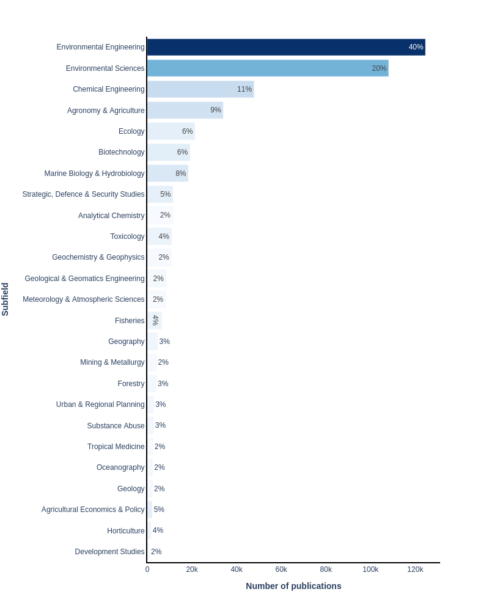

Figure 1. Top 25 subfields with the largest percentage of Scopus publication included in the publication set.

## Journals

In this section, we show how the publication set, captured by the query above, relates to scholarly journals. Journals are sorted in terms of their relevance using term frequency-inverse document frequency (TF-IDF). The horizontal bars are proportional to the number of publications contributed by the journal to the current publication set. The number alongside the horizontal bar is the proportion of the journal contributing to this publication set.

The articles on this topic are published most frequently in the following journals: *Water Science and Technology* (12,944 publications), *Science of the Total Environment* (12,258), and *Water Research* (11,120).

Note, larger journals may not appear in the table below, as their SDG contribution may be relatively small compared to the size of the journal.

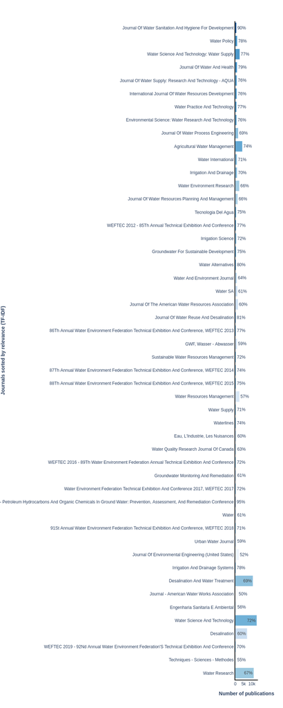

Figure 2. Top 50 journals, in terms of relevance (TF-IDF), for this publication set.

## Keywords

Elsevier’s [Scopus](https://www.scopus.com/search/form.uri?display=basic#basic) database of scientific literature, was used for the table below. The document types included in the data sets are journal articles, reviews, short surveys and conference papers, covering the period 1996–2022. We refer to these documents collectively as “publications” or “papers”.

In order to help better illustrate the content of this set of publications, indicators associated with the keywords most specific to this set (according to a TF-IDF score) are presented below.

|  | Term | # of papers with this term in the publication set | # of papers with this term in all of Scopus | Relevance (TF-IDF) | Percentage of Scopus |
| --- | --- | --- | --- | --- | --- |
| 1 | sequencing batch reactor (sbr) | 2393 | 2603 | 18.753 | 92 |
| 2 | water framework directive (wfd) | 1546 | 1687 | 18.7296 | 92 |
| 3 | european water framework directive | 1282 | 1387 | 18.7153 | 92 |
| 4 | wastewater treatment plant (wwtp) | 2910 | 3203 | 18.7147 | 91 |
| 5 | the water framework directive | 2208 | 2463 | 18.7077 | 90 |
| 6 | real wastewater | 2058 | 2305 | 18.7003 | 89 |
| 7 | surface flow constructed wetland | 1257 | 1377 | 18.6892 | 91 |
| 8 | wastewater treatment plants (wwtps) | 3617 | 3980 | 18.6808 | 91 |
| 9 | waste activated sludge (was) | 1098 | 1189 | 18.6791 | 92 |
| 10 | deficit irrigation | 3898 | 4270 | 18.6737 | 91 |

[output cut: 990 more lines]